# Data605_hw11_WZHOU

Wei Zhou

11/10/2019

Using the “cars” dataset in R, build a linear model for stopping distance as a function of speed and replicate the analysis of your textbook chapter 3 (visualization, quality evaluation of the model, and residual analysis.)

```
##      speed           dist
##  Min.   : 4.0   Min.   :  2.00
##  1st Qu.:12.0   1st Qu.: 26.00
##  Median :15.0   Median : 36.00
##  Mean   :15.4   Mean   : 42.98
##  3rd Qu.:19.0   3rd Qu.: 56.00
##  Max.   :25.0   Max.   :120.00
```

#### Data Visualization

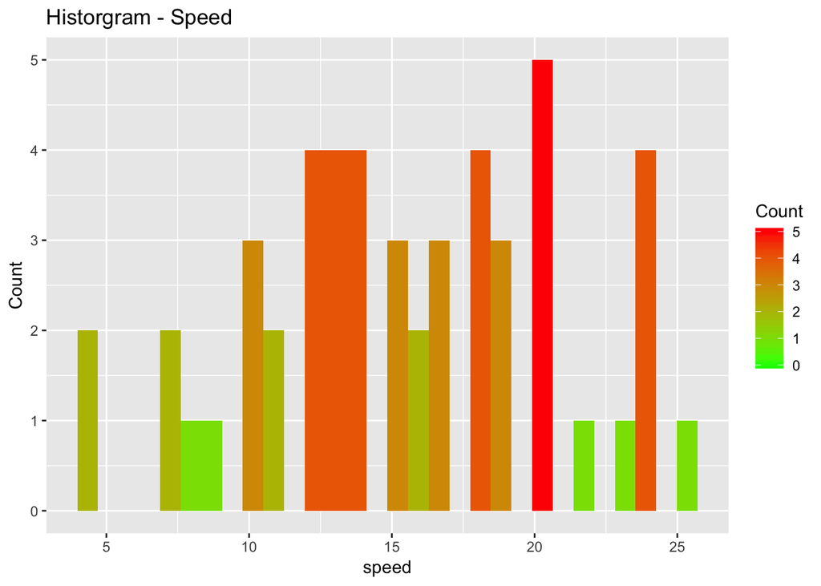

```r
ggplot(data=cars, aes(cars$speed)) +
  geom_histogram(aes(fill = ..count..)) +
  scale_fill_gradient("Count", low = "green", high = "red") +
  labs(title = "Historgram - Speed") +
  labs(x = "speed") +
  labs(y = "Count")
```

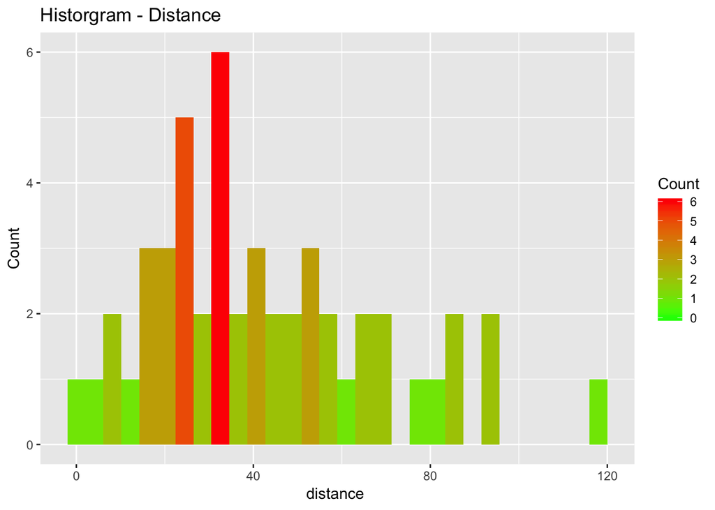

```r
ggplot(data=cars, aes(cars$dist)) +
  geom_histogram(aes(fill = ..count..)) +
  scale_fill_gradient("Count", low = "green", high = "red") +
  labs(title = "Historgram - Distance") +
  labs(x = "distance ") +
  labs(y = "Count")
```

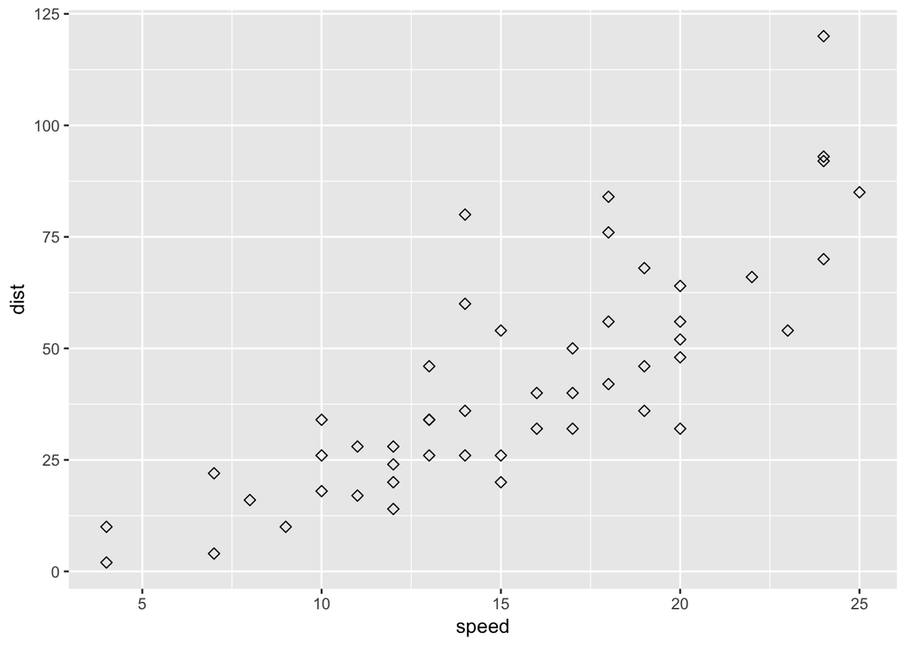

```r
ggplot(cars, aes(x=speed, y=dist)) +
  geom_point(size=2, shape=23)
```

#### Statistical Analysis

##### Correlation:

```r
cor(cars$speed, cars$dist)
```

```
## [1] 0.8068949
```

#### Modeling

Using the simple linear regression, yhat = a*x+b. b is the y-intercept of the line, a is the slope, x is speed and y is output dist. Using `lm` function we can have the model:

```r
car_model = lm(cars$dist~ cars$speed)
car_model
```

```
##
## Call:
## lm(formula = cars$dist ~ cars$speed)
##
## Coefficients:
## (Intercept)   cars$speed
##     -17.579        3.932
```

The regression model is
$$dist = 3.932 * speed - 17.579$$

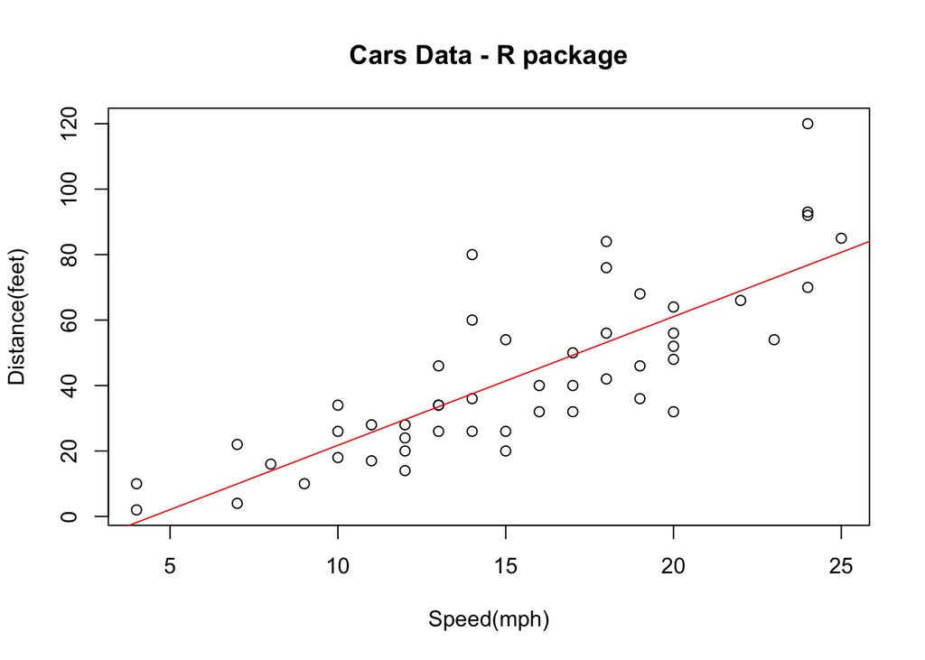

```r
plot(x = cars$speed, y = cars$dist, main="Cars Data - R package", xlab = "Speed(mph)", ylab = "Distance(feet)")
  abline(car_model, col="red")
```

#### Evaluating the Quality of the model

```r
summary(car_model)
```

```
##
## Call:
## lm(formula = cars$dist ~ cars$speed)
##
## Residuals:
##     Min      1Q  Median      3Q     Max
## -29.069  -9.525  -2.272   9.215  43.201
##
## Coefficients:
##             Estimate Std. Error t value Pr(>|t|)
## (Intercept) -17.5791     6.7584  -2.601   0.0123 *
## cars$speed    3.9324     0.4155   9.464 1.49e-12 ***
## ---
## Signif. codes:  0 '***' 0.001 '**' 0.01 '*' 0.05 '.' 0.1 ' ' 1
##
## Residual standard error: 15.38 on 48 degrees of freedom
## Multiple R-squared:  0.6511, Adjusted R-squared:  0.6438
## F-statistic: 89.57 on 1 and 48 DF,  p-value: 1.49e-12
```

The Multiple R-squared value 0.6511 means this moel could explain 65.11% of the data variation

#### Residual Analysis

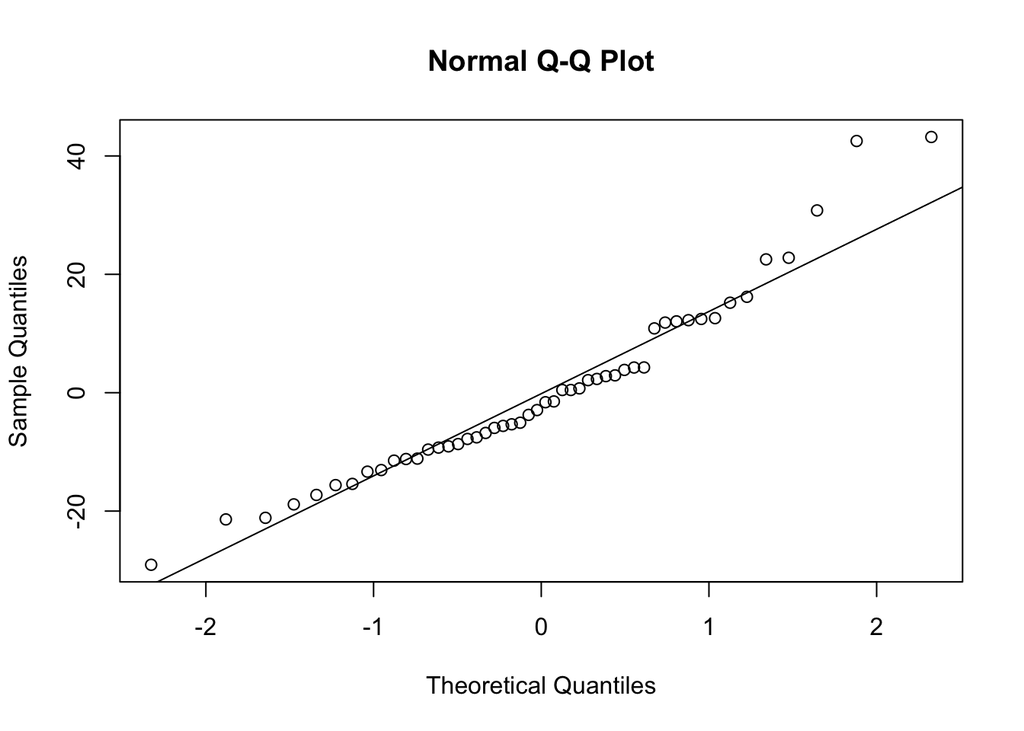

```r
qqnorm(resid(car_model))
qqline(resid(car_model))
```

#### Conclusion

We see that the data has 0.8069 correlation and 65.11% multiple R -square and QQ-plot shows that using speed as the only predictor in the model is insufficient to explain the distance. Therefore, we would suggest adding other factors into the model the make the model more reliable.